# RNA-seq data analysis training

- Guillem Ylla, Ph.D.
- Harvard University
- September 2021

Data obtained from:

- Tarikere, S., Ylla, G.,& Extavour, C. G. “Distinct gene expression dynamics in germ line and somatic tissue during ovariole morphogenesis in *Drosophila melanogaster*”, 2021.
- Github repo of the original data and analysis: https://htmlpreview.github.io/?https://raw.githubusercontent.com/guillemylla/Ovariole_morphogenesis_RNAseq/

## Load libraries

```r
library(ggplot2)
library(tidyr)
library(dplyr)
library(DESeq2)

knitr::opts_chunk$set(fig.width = 12)
knitr::opts_chunk$set(fig.height =  8)
knitr::opts_chunk$set(cache = TRUE)
knitr::opts_chunk$set(message = FALSE)
knitr::opts_chunk$set(warnings = FALSE)
```

## Load Data

```r
Metadata<-read.csv("data/Metadata.csv")
rownames(Metadata)<-Metadata$BioSample#set BioSample as rownames
Metadata
```

[output not shown]

```r
Counts<-read.csv(file="data/Counts_table.csv", row.names = 1)
head(Counts)
dim(Counts)
```

[output not shown]

## Normalitzation

- Remove genes with ZERO counts in all samples

```r
Counts_nz<-Counts[rowSums(Counts)!=0,]

dim(Counts_nz)
```

```
## [1] 14343     6
```

- Round to the unit because DESeq2 wants integer counts.

```r
Counts_nz<-round(Counts_nz,0)
```

- Make sure that the row names of the metadata file are in the same than the table of counts column name

```r
identical(colnames(Counts_nz), rownames(Metadata))
```

[output not shown]

- Load data in DESeq2. As “design” indicate the factor that we want to compare.

```r
dds <- DESeq2::DESeqDataSetFromMatrix(countData = Counts_nz,
                              colData = Metadata,
                              design= ~Stage)
#estimate factors
dds <- DESeq2::DESeq(dds)
```

- Get the VST normalized reads in case you want them for something (i.e. PCA)

```r
VST <- assay(varianceStabilizingTransformation(dds, blind=TRUE))
head(VST)
```

```
##             WholeOvary_Ctrl_Early_1 WholeOvary_Ctrl_Early_2
## FBgn0000003                7.789645                7.570247
## FBgn0000008                8.014998                7.739406
## FBgn0000014               13.335051               13.460699
## FBgn0000015                9.199437                9.315585
## FBgn0000017               10.427983               10.501534
## FBgn0000018                9.074239                9.140285
##             WholeOvary_Ctrl_Early_3 WholeOvary_Ctrl_Mid_1 WholeOvary_Ctrl_Mid_2
## FBgn0000003                6.966468              7.215057              8.281774
## FBgn0000008                8.345810              7.837458              7.563404
## FBgn0000014               13.978672             13.761720             13.354884
## FBgn0000015                9.892471              8.368087              8.068091
## FBgn0000017               10.789664             11.072218             10.553284
## FBgn0000018                9.153722              9.089848              9.276959
##             WholeOvary_Ctrl_Mid_3
## FBgn0000003              8.160909
## FBgn0000008              7.422054
## FBgn0000014             13.551819
## FBgn0000015              7.975964
## FBgn0000017             10.821510
## FBgn0000018              9.137577
```

## Differential Expression Analysis

- See top DEGs

```r
dea_result_df<-as.data.frame(results(dds, contrast = c("Stage", "Early","Mid"), alpha=0.001) )

head(dea_result_df)
```

|  | baseMean | log2FoldChange | lfcSE | stat | pvalue | padj |
| --- | --- | --- | --- | --- | --- | --- |
| FBgn0000003 | 146.0103 | -0.6846816 | 0.5201872 | -1.3162217 | 1.880996e-01 | 5.167269e-01 |
| FBgn0000008 | 162.4983 | 0.6097948 | 0.3457811 | 1.7635286 | 7.781137e-02 | 3.431535e-01 |
| FBgn0000014 | 12279.4378 | 0.0539463 | 0.2480111 | 0.2175157 | 8.278065e-01 | 9.291758e-01 |
| FBgn0000015 | 432.8364 | 1.6106297 | 0.3079033 | 5.2309590 | 1.686329e-07 | 1.144807e-05 |
| FBgn0000017 | 1602.9710 | -0.2608398 | 0.2305489 | -1.1313860 | 2.578926e-01 | 5.844419e-01 |
| FBgn0000018 | 494.3413 | -0.0525029 | 0.1805424 | -0.2908064 | 7.711994e-01 | 9.052423e-01 |

- Count DEGs

```r
dea_result_df %>%
  filter(padj <0.01 ) %>%
  dplyr::summarise(sum(log2FoldChange<0),
            sum(log2FoldChange>0))
```

| sum(log2FoldChange < 0) | sum(log2FoldChange > 0) |
| --- | --- |
| 144 | 426 |

## Graphic visualiaztion

I like to use ggplots and other Tidyverse packages, for which a long data format is better.

- Transform VST table to long foramt and add metadata

```r
VST_meta<-as.data.frame(VST) %>%
  tibble::rownames_to_column(var = "GeneID") %>%
  pivot_longer(cols=colnames(VST),names_to="Sample", values_to="VST") %>%
  left_join(Metadata, by=c("Sample"="BioSample"))

head(VST_meta)
```

| GeneID | Sample | VST | CellType | Treatment | Stage |
| --- | --- | --- | --- | --- | --- |
| FBgn0000003 | WholeOvary_Ctrl_Early_1 | 7.789645 | WholeOvary | Ctrl | Early |
| FBgn0000003 | WholeOvary_Ctrl_Early_2 | 7.570247 | WholeOvary | Ctrl | Early |
| FBgn0000003 | WholeOvary_Ctrl_Early_3 | 6.966468 | WholeOvary | Ctrl | Early |
| FBgn0000003 | WholeOvary_Ctrl_Mid_1 | 7.215057 | WholeOvary | Ctrl | Mid |
| FBgn0000003 | WholeOvary_Ctrl_Mid_2 | 8.281774 | WholeOvary | Ctrl | Mid |
| FBgn0000003 | WholeOvary_Ctrl_Mid_3 | 8.160909 | WholeOvary | Ctrl | Mid |

- Boxplot normalized data

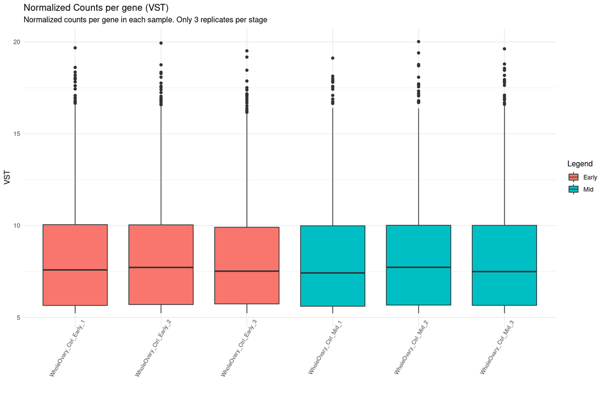

```r
Boxplot_VST <- ggplot(VST_meta, aes(x=Sample, y=VST,  fill=Stage)) +
  geom_boxplot()+
  theme_minimal()+
  theme(axis.text.x = element_text(angle = 60, hjust = .8, size=8))+
  labs(title = "Normalized Counts per gene (VST)",
              subtitle = "Normalized counts per gene in each sample. Only 3 replicates per stage",fill ="Legend")+xlab("")

Boxplot_VST
```

- PCA

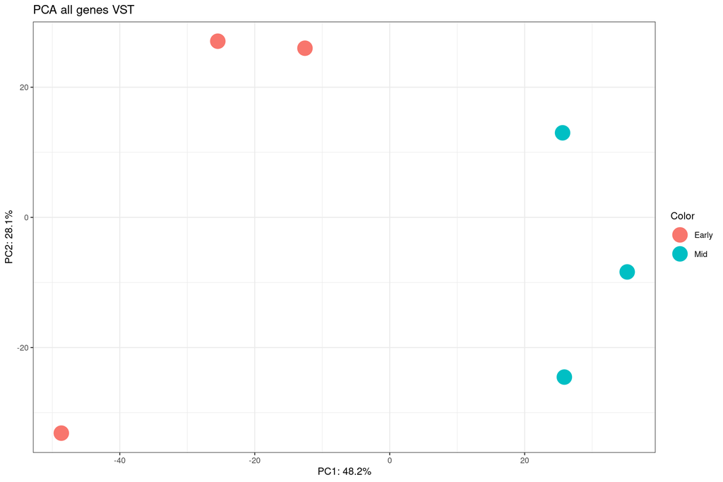

```r
## Prepare data for PCA
VST_toPCA<-t(VST) # transpose data (is how prcomp wants it)

## add metadata
VST_toPCA<-as.data.frame(VST_toPCA) %>%
    tibble::rownames_to_column(var ="BioSample") %>%
    dplyr::left_join(Metadata, by=c("BioSample"="BioSample"))

rownames(VST_toPCA)<-VST_toPCA$BioSample

#compute PCA
pca_VST<-prcomp(VST_toPCA[,2:nrow(VST)+1], scale. =FALSE  )

#get variance
var_explained <- pca_VST$sdev^2/sum(pca_VST$sdev^2)

#Plot PCA with ggplots
pca_VST_plot<-pca_VST$x %>%
  as.data.frame %>%
  ggplot(aes(x=PC1,y=PC2))  +
  geom_point(aes(color=VST_toPCA$Stage), size = 8)+
  labs(x=paste0("PC1: ",round(var_explained[1]*100,1),"%"),
       y=paste0("PC2: ",round(var_explained[2]*100,1),"%"),
       title = "PCA all genes VST",color ="Color", shape="Shape")+
  theme_bw(base_size = 12)

pca_VST_plot
```

- Volcano plot of DEA

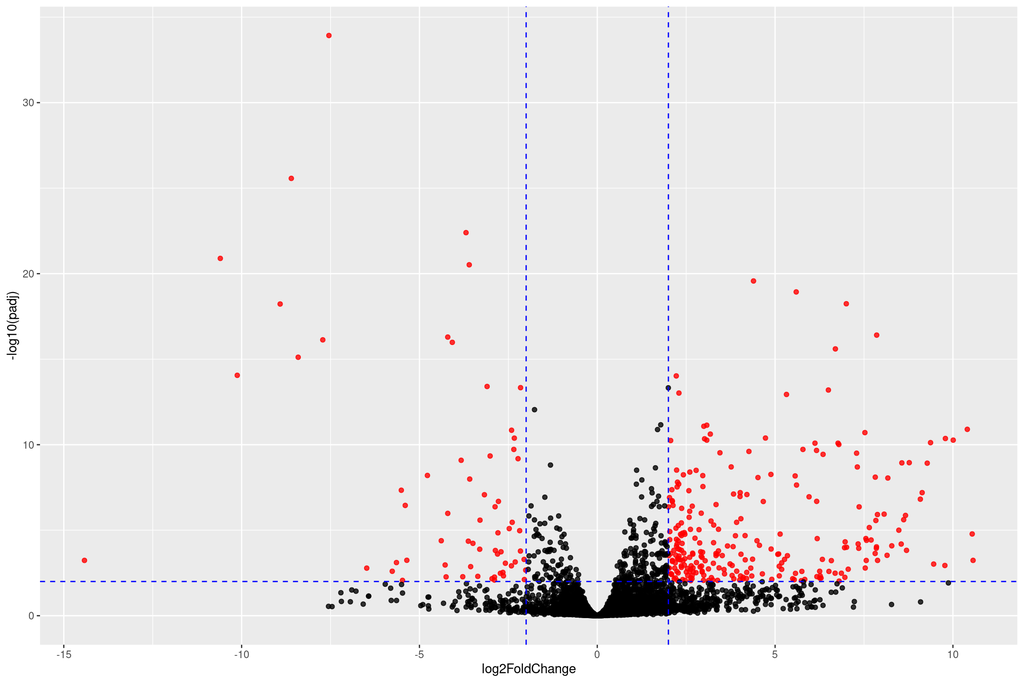

```r
ggplot(dea_result_df, aes(x=log2FoldChange, y=-log10(padj)) ) +
  geom_point(data = subset(dea_result_df, padj < 0.01 & abs(log2FoldChange)>2),   color = "red", alpha = 0.8)+
  geom_point(data = subset(dea_result_df, padj > 0.01 |  abs(log2FoldChange)<2 ),   color = "black", alpha = 0.8) +
  geom_hline(yintercept = 2, linetype = "dashed", color="blue")+
  geom_vline(xintercept = c(-2, 2), linetype = "dashed", color="blue")
```